# Computation_TSS_overlap

# 1. Analysis for E. coli only

First, we import the annotation for E. coli TSSs derived from dRNA-Seq, adjust columns and column names.

```r
ec_anno <- read.delim("U00096.3_TSS.gff", comment.char="#", stringsAsFactors=TRUE, header = FALSE)
ec_anno <- ec_anno[,-c(2,6,8)]
ec_anno[,3] <- as.numeric((as.character(ec_anno[,3])))
ec_anno[,4] <- as.numeric((as.character(ec_anno[,4])))
colnames(ec_anno) <- c("Genome", "Type", "Start", "End", "Strand", "ID")
head(ec_anno, n=6)
```

```
##     Genome Type Start  End Strand
## 1 U00096.3  TSS   148  148      +
## 2 U00096.3  TSS  1176 1176      -
## 3 U00096.3  TSS  2581 2581      +
## 4 U00096.3  TSS  2600 2600      +
## 5 U00096.3  TSS  3729 3729      -
## 6 U00096.3  TSS  5042 5042      +
##                                                                                                                                                        ID
## 1                                Name=TSS:148_f;ID=U00096.3_tss0;type=Primary;utr_length=Primary_42;associated_gene=b0001;libs=1,2,3,4;method=TSSpredator
## 2                             Name=TSS:1176_r;ID=U00096.3_tss1;type=Antisense;utr_length=Antisense_NA;associated_gene=b0002;libs=1,2,4;method=TSSpredator
## 3       Name=TSS:2581_f;ID=U00096.3_tss2;type=Primary,Internal;utr_length=Primary_220,Internal_NA;associated_gene=b0003,b0002;libs=1,2;method=TSSpredator
## 4 Name=TSS:2600_f;ID=U00096.3_tss3;type=Secondary,Internal;utr_length=Secondary_201,Internal_NA;associated_gene=b0003,b0002;libs=1,2,4;method=TSSpredator
## 5                                 Name=TSS:3729_r;ID=U00096.3_tss4;type=Antisense;utr_length=Antisense_NA;associated_gene=b0003;libs=1;method=TSSpredator
## 6                              Name=TSS:5042_f;ID=U00096.3_tss5;type=Primary;utr_length=Primary_192;associated_gene=b0005;libs=1,2,3,4;method=TSSpredator
```

Next, we import the annotations for NAD-RNA TSSs in E. coli for both runs (R1: ONTrun_061; R2: ONTrun_065).

```r
ec_061 <- read.delim("U00096-3_ONTrun_061.gff", comment.char="#", stringsAsFactors=TRUE, header = FALSE)
ec_061 <- ec_061[,-c(2,6,8,9)]
ec_061[,3] <- as.numeric((as.character(ec_061[,3])))
ec_061[,4] <- as.numeric((as.character(ec_061[,4])))
colnames(ec_061) <- c("Genome", "Type", "Start", "End", "Strand", "Gene")
head(ec_061, n=6)
```

```
##     Genome Type  Start    End Strand Gene
## 1 U00096.3  TSS  21207  21207      - yaaY
## 2 U00096.3  TSS  89589  89591      + mraZ
## 3 U00096.3  TSS 122034 122034      + pdhR
## 4 U00096.3  TSS 142703 142703      -  can
## 5 U00096.3  TSS 231072 231072      + yafD
## 6 U00096.3  TSS 255803 255807      - pepD
```

```r
ec_065 <- read.delim("U00096-3_ONTrun_065.gff", comment.char="#", stringsAsFactors=TRUE, header = FALSE)
ec_065 <- ec_065[,-c(2,6,8,9)]
ec_065[,3] <- as.numeric((as.character(ec_065[,3])))
ec_065[,4] <- as.numeric((as.character(ec_065[,4])))
colnames(ec_065) <- c("Genome", "Type", "Start", "End", "Strand", "Gene")
head(ec_065, n=6)
```

```
##     Genome Type   Start     End Strand Gene
## 1 U00096.3  TSS 1151512 1151512      + acpP
## 2 U00096.3  TSS 2365723 2365723      -  ais
## 3 U00096.3  TSS  473940  473940      + amtB
## 4 U00096.3  TSS 2818645 2818700      - argV
## 5 U00096.3  TSS 4368431 4368431      - aspA
## 6 U00096.3  TSS 4332095 4332095      + basS
```

## 1.1 Search for proximal TSS from E. coli annotation

The TSS from NAD captureSeq data are sometimes annotated as short intervals instead of one distinct coordinate (start=end). In rare cases, this may also be true for the TSS determined with dRNA-Seq. Thus, the rowMeans for the NAD_TSS interval is taken to search within a window of +/- 8 bases of the true TSS. A match is then return by fusing the two rows by appending them in one data frame. This data fram can later be used to compare mean displacement of NAD_TSS and True_TSS.

```r
search_TSS <- function(x,y){
  df <- as.data.frame(cbind(x,y[1:nrow(x),]))
  i <- 1
  while(i<=nrow(x)){
    z <- rowMeans(x[i,3:4])
    j <- 1
    while(j<=nrow(y)){
      a <- rowMeans(y[j,3:4])
      if (z<=a+8 && z>=a-8) {
        df[i,1:ncol(x)] <- x[i,]
        df[i,(ncol(x)+1):(ncol(x)+ncol(y))] <- y[j,]
        j <- nrow(y)+1
      } else {
        j <- j+1
      }
    }
    if(df[i,9] == y[i,3]){
      df[i,(ncol(x)+1):(ncol(x)+ncol(y))] <- c(NA, NA, 0, 0, NA, NA)
    }
    i <- i+1
  }
  colnames(df) <- c("Genome_NAD", "Type_NAD", "Start_NAD", "End_NAD", "Strand_NAD", "Gene_NAD", "Genome_TSS", "Type_TSS", "Start_TSS", "End_TSS", "Strand_TSS", "Gene_TSS")
  return(df)
}

df_061 <- search_TSS(ec_061, ec_anno)
head(df_061, n=6)
```

```
##   Genome_NAD Type_NAD Start_NAD End_NAD Strand_NAD Gene_NAD Genome_TSS Type_TSS
## 1   U00096.3      TSS     21207   21207          -     yaaY   U00096.3      TSS
## 2   U00096.3      TSS     89589   89591          +     mraZ   U00096.3      TSS
## 3   U00096.3      TSS    122034  122034          +     pdhR   U00096.3      TSS
## 4   U00096.3      TSS    142703  142703          -      can   U00096.3      TSS
## 5   U00096.3      TSS    231072  231072          +     yafD   U00096.3      TSS
## 6   U00096.3      TSS    255803  255807          -     pepD   U00096.3      TSS
##   Start_TSS End_TSS Strand_TSS
## 1     21207   21207          -
## 2     89589   89589          +
## 3    122034  122034          +
## 4    142703  142703          -
## 5    231072  231072          +
## 6    255807  255807          -
##                                                                                                                                                     Gene_TSS
## 1  Name=TSS:21207_r;ID=U00096.3_tss34;type=Primary,Antisense;utr_length=Primary_129,Antisense_NA;associated_gene=b0023,b0024;libs=1,2,3,4;method=TSSpredator
## 2                                Name=TSS:89589_f;ID=U00096.3_tss94;type=Primary;utr_length=Primary_45;associated_gene=b0081;libs=1,2,3,4;method=TSSpredator
## 3                              Name=TSS:122034_f;ID=U00096.3_tss132;type=Primary;utr_length=Primary_58;associated_gene=b0113;libs=1,2,3,4;method=TSSpredator
## 4 Name=TSS:142703_r;ID=U00096.3_tss157;type=Primary,Antisense;utr_length=Primary_33,Antisense_NA;associated_gene=b0126,b0127;libs=1,2,3,4;method=TSSpredator
## 5                              Name=TSS:231072_f;ID=U00096.3_tss306;type=Primary;utr_length=Primary_50;associated_gene=b0209;libs=1,2,3,4;method=TSSpredator
## 6                              Name=TSS:255807_r;ID=U00096.3_tss332;type=Primary;utr_length=Primary_91;associated_gene=b0237;libs=1,2,3,4;method=TSSpredator
```

```r
df_065 <- search_TSS(ec_065, ec_anno)
head(df_065, n=6)
```

```
##   Genome_NAD Type_NAD Start_NAD End_NAD Strand_NAD Gene_NAD Genome_TSS Type_TSS
## 1   U00096.3      TSS   1151512 1151512          +     acpP   U00096.3      TSS
## 2   U00096.3      TSS   2365723 2365723          -      ais   U00096.3      TSS
## 3   U00096.3      TSS    473940  473940          +     amtB   U00096.3      TSS
## 4   U00096.3      TSS   2818645 2818700          -     argV       <NA>     <NA>
## 5   U00096.3      TSS   4368431 4368431          -     aspA   U00096.3      TSS
## 6   U00096.3      TSS   4332095 4332095          +     basS   U00096.3      TSS
##   Start_TSS End_TSS Strand_TSS
## 1   1151512 1151512          +
## 2   2365715 2365715          +
## 3    473940  473940          +
## 4         0       0       <NA>
## 5   4368431 4368431          -
## 6   4332088 4332088          -
##                                                                                                                                                            Gene_TSS
## 1                                  Name=TSS:1151512_f;ID=U00096.3_tss1330;type=Primary;utr_length=Primary_103;associated_gene=b1094;libs=1,2,3,4;method=TSSpredator
## 2 Name=TSS:2365715_f;ID=U00096.3_tss2568;type=Secondary,Antisense;utr_length=Secondary_195,Antisense_NA;associated_gene=b2253,b2252;libs=1,2,3,4;method=TSSpredator
## 3                                         Name=TSS:473940_f;ID=U00096.3_tss532;type=Internal;utr_length=Internal_NA;associated_gene=b0451;libs=2;method=TSSpredator
## 4                                                                                                                                                              <NA>
## 5                                  Name=TSS:4368431_r;ID=U00096.3_tss5030;type=Primary;utr_length=Primary_104;associated_gene=b4139;libs=1,2,3,4;method=TSSpredator
## 6                                     Name=TSS:4332088_r;ID=U00096.3_tss4982;type=Antisense;utr_length=Antisense_NA;associated_gene=b4111;libs=1;method=TSSpredator
```

## 1.2 Compute mean deviation for NAD_TSS from True_TSS

Create a function which calculates the mean for each NAD_TSS and True_TSS and compare its mean deviation as a number.

```r
TSS_displacement <- function(x){
  z <- as.data.frame(cbind(x,x[,3],x[,7],x[,7]))
  z[,14] <- as.character(z[,14])
  z[,15] <- as.character(z[,15])
  i <- 1
  while(i<=nrow(x)){
    if(x[i,9]==0){
      z[i,13] <- 9
      z[i,14] <- NA
      z[i,15] <- NA
    }else if(x[i,9]!=0){
      z[i,13] <- abs(rowMeans(x[i,3:4])-rowMeans(x[i,9:10]))
      if(str_detect(str_split(str_split(x[i,12], ";")[[1]][3], "=")[[1]][2], ",")){
        z[i,14] <- str_split(str_split(str_split(x[i,12], ";")[[1]][3], "=")[[1]][2], ",")[[1]][1]
        z[i,15] <- str_split(str_split(str_split(x[i,12], ";")[[1]][3], "=")[[1]][2], ",")[[1]][2]
      }else if (str_detect(str_split(str_split(x[i,12], ";")[[1]][3], "=")[[1]][2], ",") == FALSE){
        z[i,14] <- str_split(str_split(x[i,12], ";")[[1]][3], "=")[[1]][2]
        z[i,15] <- NA
      }
    }
    i <- i+1
  }
  return(z)
}

df_061_calc <- TSS_displacement(df_061)
colnames(df_061_calc) <- c("Genome_NAD", "Type_NAD", "Start_NAD", "End_NAD", "Strand_NAD", "Gene_NAD", "Genome_TSS", "Type_TSS", "Start_TSS", "End_TSS", "Strand_TSS", "Gene_TSS", "Displacement", "TSS_Kind", "TSS_2nd_Kind")
head(df_061_calc, n=6)
```

```
##   Genome_NAD Type_NAD Start_NAD End_NAD Strand_NAD Gene_NAD Genome_TSS Type_TSS
## 1   U00096.3      TSS     21207   21207          -     yaaY   U00096.3      TSS
## 2   U00096.3      TSS     89589   89591          +     mraZ   U00096.3      TSS
## 3   U00096.3      TSS    122034  122034          +     pdhR   U00096.3      TSS
## 4   U00096.3      TSS    142703  142703          -      can   U00096.3      TSS
## 5   U00096.3      TSS    231072  231072          +     yafD   U00096.3      TSS
## 6   U00096.3      TSS    255803  255807          -     pepD   U00096.3      TSS
##   Start_TSS End_TSS Strand_TSS
## 1     21207   21207          -
## 2     89589   89589          +
## 3    122034  122034          +
## 4    142703  142703          -
## 5    231072  231072          +
## 6    255807  255807          -
##                                                                                                                                                     Gene_TSS
## 1  Name=TSS:21207_r;ID=U00096.3_tss34;type=Primary,Antisense;utr_length=Primary_129,Antisense_NA;associated_gene=b0023,b0024;libs=1,2,3,4;method=TSSpredator
## 2                                Name=TSS:89589_f;ID=U00096.3_tss94;type=Primary;utr_length=Primary_45;associated_gene=b0081;libs=1,2,3,4;method=TSSpredator
## 3                              Name=TSS:122034_f;ID=U00096.3_tss132;type=Primary;utr_length=Primary_58;associated_gene=b0113;libs=1,2,3,4;method=TSSpredator
## 4 Name=TSS:142703_r;ID=U00096.3_tss157;type=Primary,Antisense;utr_length=Primary_33,Antisense_NA;associated_gene=b0126,b0127;libs=1,2,3,4;method=TSSpredator
## 5                              Name=TSS:231072_f;ID=U00096.3_tss306;type=Primary;utr_length=Primary_50;associated_gene=b0209;libs=1,2,3,4;method=TSSpredator
## 6                              Name=TSS:255807_r;ID=U00096.3_tss332;type=Primary;utr_length=Primary_91;associated_gene=b0237;libs=1,2,3,4;method=TSSpredator
##   Displacement TSS_Kind TSS_2nd_Kind
## 1            0  Primary    Antisense
## 2            1  Primary         <NA>
## 3            0  Primary         <NA>
## 4            0  Primary    Antisense
## 5            0  Primary         <NA>
## 6            2  Primary         <NA>
```

```r
df_065_calc <- TSS_displacement(df_065)
colnames(df_065_calc) <- c("Genome_NAD", "Type_NAD", "Start_NAD", "End_NAD", "Strand_NAD", "Gene_NAD", "Genome_TSS", "Type_TSS", "Start_TSS", "End_TSS", "Strand_TSS", "Gene_TSS", "Displacement", "TSS_Kind", "TSS_2nd_Kind")
head(df_065_calc, n=6)
```

```
##   Genome_NAD Type_NAD Start_NAD End_NAD Strand_NAD Gene_NAD Genome_TSS Type_TSS
## 1   U00096.3      TSS   1151512 1151512          +     acpP   U00096.3      TSS
## 2   U00096.3      TSS   2365723 2365723          -      ais   U00096.3      TSS
## 3   U00096.3      TSS    473940  473940          +     amtB   U00096.3      TSS
## 4   U00096.3      TSS   2818645 2818700          -     argV       <NA>     <NA>
## 5   U00096.3      TSS   4368431 4368431          -     aspA   U00096.3      TSS
## 6   U00096.3      TSS   4332095 4332095          +     basS   U00096.3      TSS
##   Start_TSS End_TSS Strand_TSS
## 1   1151512 1151512          +
## 2   2365715 2365715          +
## 3    473940  473940          +
## 4         0       0       <NA>
## 5   4368431 4368431          -
## 6   4332088 4332088          -
##                                                                                                                                                            Gene_TSS
## 1                                  Name=TSS:1151512_f;ID=U00096.3_tss1330;type=Primary;utr_length=Primary_103;associated_gene=b1094;libs=1,2,3,4;method=TSSpredator
## 2 Name=TSS:2365715_f;ID=U00096.3_tss2568;type=Secondary,Antisense;utr_length=Secondary_195,Antisense_NA;associated_gene=b2253,b2252;libs=1,2,3,4;method=TSSpredator
## 3                                         Name=TSS:473940_f;ID=U00096.3_tss532;type=Internal;utr_length=Internal_NA;associated_gene=b0451;libs=2;method=TSSpredator
## 4                                                                                                                                                              <NA>
## 5                                  Name=TSS:4368431_r;ID=U00096.3_tss5030;type=Primary;utr_length=Primary_104;associated_gene=b4139;libs=1,2,3,4;method=TSSpredator
## 6                                     Name=TSS:4332088_r;ID=U00096.3_tss4982;type=Antisense;utr_length=Antisense_NA;associated_gene=b4111;libs=1;method=TSSpredator
##   Displacement  TSS_Kind TSS_2nd_Kind
## 1            0   Primary         <NA>
## 2            8 Secondary    Antisense
## 3            0  Internal         <NA>
## 4            9      <NA>         <NA>
## 5            0   Primary         <NA>
## 6            7 Antisense         <NA>
```

## 1.3 Plot information on overlapping of NAD_TSS and True_TSS

Therefore, filter for relevant columns and then create plot.

```r
df_061_plot <- df_061_calc[,c(5,6,13,14)]
head(df_061_plot, n=6)
```

```
##   Strand_NAD Gene_NAD Displacement TSS_Kind
## 1          -     yaaY            0  Primary
## 2          +     mraZ            1  Primary
## 3          +     pdhR            0  Primary
## 4          -      can            0  Primary
## 5          +     yafD            0  Primary
## 6          -     pepD            2  Primary
```

```r
df_065_plot <- df_065_calc[,c(5,6,13,14)]
head(df_065_plot, n=6)
```

```
##   Strand_NAD Gene_NAD Displacement  TSS_Kind
## 1          +     acpP            0   Primary
## 2          -      ais            8 Secondary
## 3          +     amtB            0  Internal
## 4          -     argV            9      <NA>
## 5          -     aspA            0   Primary
## 6          +     basS            7 Antisense
```

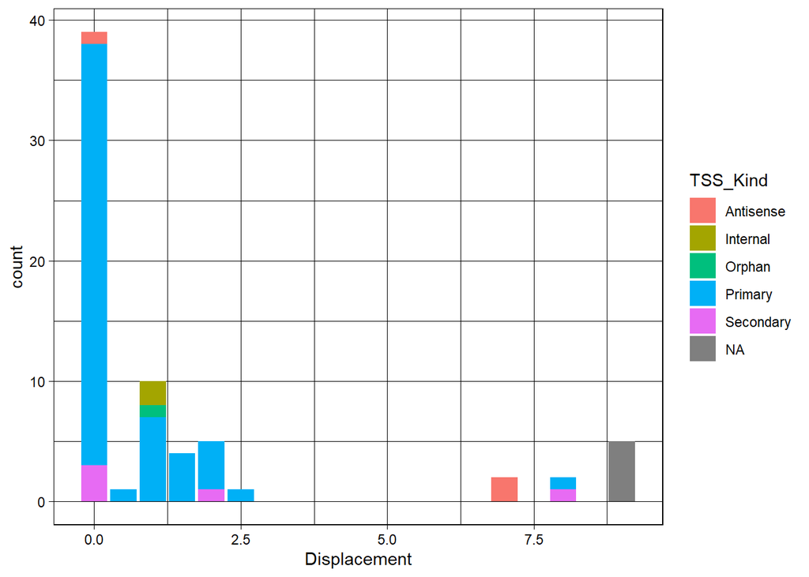

```r
p061 <- ggplot(df_061_plot, aes(Displacement))+
  geom_bar(aes(fill=TSS_Kind))+
  theme_linedraw()
p061
```

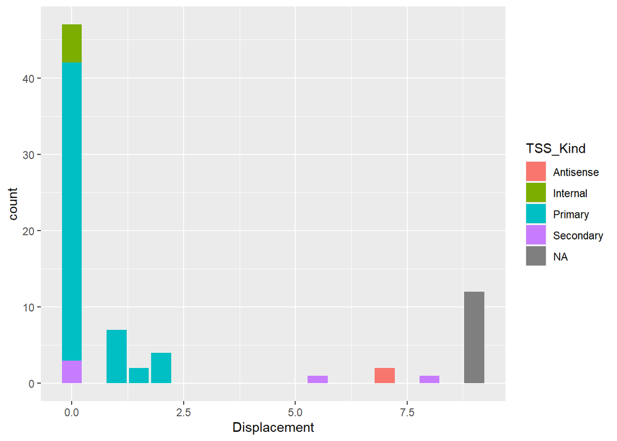

```r
p065 <- ggplot(df_065_plot, aes(Displacement))+
  geom_bar(aes(fill=TSS_Kind))
p065
```

```r
#Mean displacement
r1 <- sum(df_061_plot$Displacement)/nrow(df_061_plot)
r1
```

```
## [1] 1.507246
```

```r
r2 <- sum(df_065_plot$Displacement)/nrow(df_065_plot)
r2
```

```
## [1] 2.019737
```

## 1.4 Plot information on TSS type abundance

Therefore, count appearance of each TSS type and create a table for the pie chart.

```r
count_appearance <- function(x){
  z <- data.frame(unique(x[,14]), x[length(unique(x[,14])),13])
  z[,2] <- 0
  i <- 1
  while(i<=nrow(x)){
    if(is.na(x[i,14])){
      z[which(is.na(z[,1])),2] <- z[which(is.na(z[,1])),2]+1
    } else if(x[i,14]=="Primary"){
      z[which(z[,1] == "Primary"),2] <- z[which(z[,1] == "Primary"),2]+1
    } else if(x[i,14] == "Secondary"){
      z[which(z[,1] == "Secondary"),2] <- z[which(z[,1] == "Secondary"),2]+1
    } else if(x[i,14] == "Antisense"){
      z[which(z[,1] == "Antisense"),2] <- z[which(z[,1] == "Antisense"),2]+1
    } else if(x[i,14] == "Orphan"){
      z[which(z[,1] == "Orphan"),2] <- z[which(z[,1] == "Orphan"),2]+1
    } else if(x[i,14] == "Internal"){
      z[which(z[,1] == "Internal"),2] <- z[which(z[,1] == "Internal"),2]+1
    }
    i <- i+1
  }
  colnames(z) <- c("Type", "Count")
  return(z)
}

df_pie_061 <- count_appearance(df_061_calc)
df_pie_061
```

```
##        Type Count
## 1   Primary    53
## 2 Secondary     5
## 3 Antisense     3
## 4    Orphan     1
## 5      <NA>     5
## 6  Internal     2
```

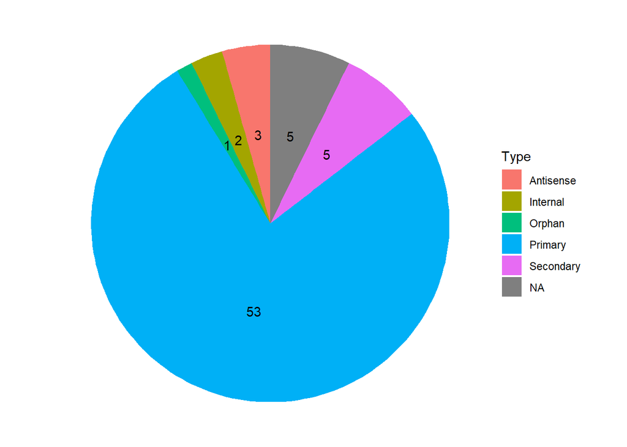

```r
pie061 <- ggplot(df_pie_061, aes(x="", y=Count, fill=Type))+
  geom_bar(width = 1, stat = "identity")+
  coord_polar("y", start=0)+
  geom_text(aes(label = Count), position = position_stack(vjust = 0.5))+
  theme_void()
pie061
```

```r
df_pie_065 <- count_appearance(df_065_calc)
df_pie_065
```

```
##        Type Count
## 1   Primary    52
## 2 Secondary     5
## 3  Internal     5
## 4      <NA>    12
## 5 Antisense     2
```

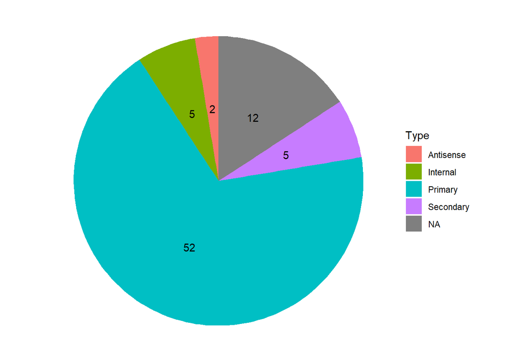

```r
pie065 <- ggplot(df_pie_065, aes(x="", y=Count, fill=Type))+
  geom_bar(width = 1, stat = "identity")+
  coord_polar("y", start=0)+
  geom_text(aes(label = Count), position = position_stack(vjust = 0.5))+
  theme_void()
pie065
```

# 2. Analysis for T4 phage only

First, we import the annotation for T4 phage TSSs derived from dRNA-Seq, adjust columns and column names.

```r
t4_anno <- read.delim("NC_000866.4_TSS.gff", comment.char="#", stringsAsFactors=TRUE, header = FALSE)
t4_anno <- t4_anno[,-c(2,6,8)]
t4_anno[,3] <- as.numeric((as.character(t4_anno[,3])))
t4_anno[,4] <- as.numeric((as.character(t4_anno[,4])))
colnames(t4_anno) <- c("Genome", "Type", "Start", "End", "Strand", "ID")
head(t4_anno, n=6)
```

```
##        Genome Type Start  End Strand
## 1 NC_000866.4  TSS  2423 2423      -
## 2 NC_000866.4  TSS  2799 2799      +
## 3 NC_000866.4  TSS  3072 3072      -
## 4 NC_000866.4  TSS  3195 3195      -
## 5 NC_000866.4  TSS  5587 5587      -
## 6 NC_000866.4  TSS  6594 6594      -
##                                                                                                                                                             ID
## 1                                      Name=TSS:2423_r;ID=NC_000866.4_tss0;type=Primary;utr_length=Primary_20;associated_gene=T4p002;libs=2;method=TSSpredator
## 2                                  Name=TSS:2799_f;ID=NC_000866.4_tss1;type=Antisense;utr_length=Antisense_NA;associated_gene=T4p003;libs=4;method=TSSpredator
## 3      Name=TSS:3072_r;ID=NC_000866.4_tss2;type=Primary,Internal;utr_length=Primary_82,Internal_NA;associated_gene=T4p003,T4p004;libs=2,3,4;method=TSSpredator
## 4 Name=TSS:3195_r;ID=NC_000866.4_tss3;type=Secondary,Internal;utr_length=Secondary_205,Internal_NA;associated_gene=T4p003,T4p004;libs=2,3,4;method=TSSpredator
## 5     Name=TSS:5587_r;ID=NC_000866.4_tss4;type=Primary,Internal;utr_length=Primary_259,Internal_NA;associated_gene=T4p006,T4p007;libs=2,3,4;method=TSSpredator
## 6                                 Name=TSS:6594_r;ID=NC_000866.4_tss5;type=Primary;utr_length=Primary_112;associated_gene=T4p010;libs=2,3,4;method=TSSpredator
```

Next, we import the annotations for NAD-RNA TSSs in T4 for both runs (R1: ONTrun_061; R2: ONTrun_065).

```r
t4_061 <- read.delim("NC_000866-4_ONTrun_061.gff", comment.char="#", stringsAsFactors=TRUE, header = FALSE)
t4_061 <- t4_061[,-c(2,6,8,9)]
t4_061[,3] <- as.numeric((as.character(t4_061[,3])))
t4_061[,4] <- as.numeric((as.character(t4_061[,4])))
colnames(t4_061) <- c("Genome", "Type", "Start", "End", "Strand", "Gene")
head(t4_061, n=6)
```

```
##        Genome Type Start   End Strand      Gene
## 1 NC_000866.4  TSS  3196  3196      -      60.1
## 2 NC_000866.4  TSS  6590  6594      -       cef
## 3 NC_000866.4  TSS 11138 11138      -     dda.1
## 4 NC_000866.4  TSS 15252 15252      - mrh1_mrh2
## 5 NC_000866.4  TSS 16794 16804      -        56
## 6 NC_000866.4  TSS 17617 17619      -       dam
```

```r
t4_065 <- read.delim("NC_000866-4_ONTrun_065.gff", comment.char="#", stringsAsFactors=TRUE, header = FALSE)
t4_065 <- t4_065[,-c(2,6,8,9)]
t4_065[,3] <- as.numeric((as.character(t4_065[,3])))
t4_065[,4] <- as.numeric((as.character(t4_065[,4])))
colnames(t4_065) <- c("Genome", "Type", "Start", "End", "Strand", "Gene")
head(t4_065, n=6)
```

```
##        Genome Type Start   End Strand  Gene
## 1 NC_000866.4  TSS  3196  3196      -  60.1
## 2 NC_000866.4  TSS  6594  6594      -   cef
## 3 NC_000866.4  TSS 11138 11138      - dda.1
## 4 NC_000866.4  TSS 15252 15252      - mrh.2
## 5 NC_000866.4  TSS 16797 16813      -    56
## 6 NC_000866.4  TSS 20070 20073      -    sp
```

## 2.1 Search for proximal TSS from T4 annotation

The TSS from NAD captureSeq data are sometimes annotated as short intervals instead of one distinct coordinate (start=end). In rare cases, this may also be true for the TSS determined with dRNA-Seq. Thus, the rowMeans for the NAD_TSS interval is taken to search within a window of +/- 8 bases of the true TSS. A match is then return by fusing the two rows by appending them in one data frame. This data fram can later be used to compare mean displacement of NAD_TSS and True_TSS.

```r
t4_df_061 <- search_TSS(t4_061, t4_anno)
head(t4_df_061, n=6)
```

```
##    Genome_NAD Type_NAD Start_NAD End_NAD Strand_NAD  Gene_NAD  Genome_TSS
## 1 NC_000866.4      TSS      3196    3196          -      60.1 NC_000866.4
## 2 NC_000866.4      TSS      6590    6594          -       cef NC_000866.4
## 3 NC_000866.4      TSS     11138   11138          -     dda.1 NC_000866.4
## 4 NC_000866.4      TSS     15252   15252          - mrh1_mrh2 NC_000866.4
## 5 NC_000866.4      TSS     16794   16804          -        56        <NA>
## 6 NC_000866.4      TSS     17617   17619          -       dam        <NA>
##   Type_TSS Start_TSS End_TSS Strand_TSS
## 1      TSS      3195    3195          -
## 2      TSS      6594    6594          -
## 3      TSS     11138   11138          -
## 4      TSS     15252   15252          -
## 5     <NA>         0       0       <NA>
## 6     <NA>         0       0       <NA>
##                                                                                                                                                       Gene_TSS
## 1 Name=TSS:3195_r;ID=NC_000866.4_tss3;type=Secondary,Internal;utr_length=Secondary_205,Internal_NA;associated_gene=T4p003,T4p004;libs=2,3,4;method=TSSpredator
## 2                                 Name=TSS:6594_r;ID=NC_000866.4_tss5;type=Primary;utr_length=Primary_112;associated_gene=T4p010;libs=2,3,4;method=TSSpredator
## 3    Name=TSS:11138_r;ID=NC_000866.4_tss9;type=Primary,Internal;utr_length=Primary_101,Internal_NA;associated_gene=T4p018,T4p019;libs=2,3,4;method=TSSpredator
## 4                              Name=TSS:15252_r;ID=NC_000866.4_tss13;type=Primary;utr_length=Primary_20;associated_gene=T4p028;libs=1,2,3,4;method=TSSpredator
## 5                                                                                                                                                         <NA>
## 6                                                                                                                                                         <NA>
```

```r
t4_df_065 <- search_TSS(t4_065, t4_anno)
head(t4_df_065, n=6)
```

```
##    Genome_NAD Type_NAD Start_NAD End_NAD Strand_NAD Gene_NAD  Genome_TSS
## 1 NC_000866.4      TSS      3196    3196          -     60.1 NC_000866.4
## 2 NC_000866.4      TSS      6594    6594          -      cef NC_000866.4
## 3 NC_000866.4      TSS     11138   11138          -    dda.1 NC_000866.4
## 4 NC_000866.4      TSS     15252   15252          -    mrh.2 NC_000866.4
## 5 NC_000866.4      TSS     16797   16813          -       56 NC_000866.4
## 6 NC_000866.4      TSS     20070   20073          -       sp NC_000866.4
##   Type_TSS Start_TSS End_TSS Strand_TSS
## 1      TSS      3195    3195          -
## 2      TSS      6594    6594          -
## 3      TSS     11138   11138          -
## 4      TSS     15252   15252          -
## 5      TSS     16813   16813          -
## 6      TSS     20073   20073          -
##                                                                                                                                                       Gene_TSS
## 1 Name=TSS:3195_r;ID=NC_000866.4_tss3;type=Secondary,Internal;utr_length=Secondary_205,Internal_NA;associated_gene=T4p003,T4p004;libs=2,3,4;method=TSSpredator
## 2                                 Name=TSS:6594_r;ID=NC_000866.4_tss5;type=Primary;utr_length=Primary_112;associated_gene=T4p010;libs=2,3,4;method=TSSpredator
## 3    Name=TSS:11138_r;ID=NC_000866.4_tss9;type=Primary,Internal;utr_length=Primary_101,Internal_NA;associated_gene=T4p018,T4p019;libs=2,3,4;method=TSSpredator
## 4                              Name=TSS:15252_r;ID=NC_000866.4_tss13;type=Primary;utr_length=Primary_20;associated_gene=T4p028;libs=1,2,3,4;method=TSSpredator
## 5                                Name=TSS:16813_r;ID=NC_000866.4_tss15;type=Primary;utr_length=Primary_28;associated_gene=T4p031;libs=2,3,4;method=TSSpredator
## 6                                Name=TSS:20073_r;ID=NC_000866.4_tss19;type=Primary;utr_length=Primary_22;associated_gene=T4p036;libs=2,3,4;method=TSSpredator
```

## 2.2 Compute mean deviation for NAD_TSS from True_TSS

Create a function which calculates the mean for each NAD_TSS and True_TSS and compare its mean deviation as a number.

```r
t4_df_061_calc <- TSS_displacement(t4_df_061)
colnames(t4_df_061_calc) <- c("Genome_NAD", "Type_NAD", "Start_NAD", "End_NAD", "Strand_NAD", "Gene_NAD", "Genome_TSS", "Type_TSS", "Start_TSS", "End_TSS", "Strand_TSS", "Gene_TSS", "Displacement", "TSS_Kind", "TSS_2nd_Kind")
head(t4_df_061_calc, n=6)
```

```
##    Genome_NAD Type_NAD Start_NAD End_NAD Strand_NAD  Gene_NAD  Genome_TSS
## 1 NC_000866.4      TSS      3196    3196          -      60.1 NC_000866.4
## 2 NC_000866.4      TSS      6590    6594          -       cef NC_000866.4
## 3 NC_000866.4      TSS     11138   11138          -     dda.1 NC_000866.4
## 4 NC_000866.4      TSS     15252   15252          - mrh1_mrh2 NC_000866.4
## 5 NC_000866.4      TSS     16794   16804          -        56        <NA>
## 6 NC_000866.4      TSS     17617   17619          -       dam        <NA>
##   Type_TSS Start_TSS End_TSS Strand_TSS
## 1      TSS      3195    3195          -
## 2      TSS      6594    6594          -
## 3      TSS     11138   11138          -
## 4      TSS     15252   15252          -
## 5     <NA>         0       0       <NA>
## 6     <NA>         0       0       <NA>
##                                                                                                                                                       Gene_TSS
## 1 Name=TSS:3195_r;ID=NC_000866.4_tss3;type=Secondary,Internal;utr_length=Secondary_205,Internal_NA;associated_gene=T4p003,T4p004;libs=2,3,4;method=TSSpredator
## 2                                 Name=TSS:6594_r;ID=NC_000866.4_tss5;type=Primary;utr_length=Primary_112;associated_gene=T4p010;libs=2,3,4;method=TSSpredator
## 3    Name=TSS:11138_r;ID=NC_000866.4_tss9;type=Primary,Internal;utr_length=Primary_101,Internal_NA;associated_gene=T4p018,T4p019;libs=2,3,4;method=TSSpredator
## 4                              Name=TSS:15252_r;ID=NC_000866.4_tss13;type=Primary;utr_length=Primary_20;associated_gene=T4p028;libs=1,2,3,4;method=TSSpredator
## 5                                                                                                                                                         <NA>
## 6                                                                                                                                                         <NA>
##   Displacement  TSS_Kind TSS_2nd_Kind
## 1            1 Secondary     Internal
## 2            2   Primary         <NA>
## 3            0   Primary     Internal
## 4            0   Primary         <NA>
## 5            9      <NA>         <NA>
## 6            9      <NA>         <NA>
```

```r
t4_df_065_calc <- TSS_displacement(t4_df_065)
colnames(t4_df_065_calc) <- c("Genome_NAD", "Type_NAD", "Start_NAD", "End_NAD", "Strand_NAD", "Gene_NAD", "Genome_TSS", "Type_TSS", "Start_TSS", "End_TSS", "Strand_TSS", "Gene_TSS", "Displacement", "TSS_Kind", "TSS_2nd_Kind")
head(t4_df_065_calc, n=6)
```

```
##    Genome_NAD Type_NAD Start_NAD End_NAD Strand_NAD Gene_NAD  Genome_TSS
## 1 NC_000866.4      TSS      3196    3196          -     60.1 NC_000866.4
## 2 NC_000866.4      TSS      6594    6594          -      cef NC_000866.4
## 3 NC_000866.4      TSS     11138   11138          -    dda.1 NC_000866.4
## 4 NC_000866.4      TSS     15252   15252          -    mrh.2 NC_000866.4
## 5 NC_000866.4      TSS     16797   16813          -       56 NC_000866.4
## 6 NC_000866.4      TSS     20070   20073          -       sp NC_000866.4
##   Type_TSS Start_TSS End_TSS Strand_TSS
## 1      TSS      3195    3195          -
## 2      TSS      6594    6594          -
## 3      TSS     11138   11138          -
## 4      TSS     15252   15252          -
## 5      TSS     16813   16813          -
## 6      TSS     20073   20073          -
##                                                                                                                                                       Gene_TSS
## 1 Name=TSS:3195_r;ID=NC_000866.4_tss3;type=Secondary,Internal;utr_length=Secondary_205,Internal_NA;associated_gene=T4p003,T4p004;libs=2,3,4;method=TSSpredator
## 2                                 Name=TSS:6594_r;ID=NC_000866.4_tss5;type=Primary;utr_length=Primary_112;associated_gene=T4p010;libs=2,3,4;method=TSSpredator
## 3    Name=TSS:11138_r;ID=NC_000866.4_tss9;type=Primary,Internal;utr_length=Primary_101,Internal_NA;associated_gene=T4p018,T4p019;libs=2,3,4;method=TSSpredator
## 4                              Name=TSS:15252_r;ID=NC_000866.4_tss13;type=Primary;utr_length=Primary_20;associated_gene=T4p028;libs=1,2,3,4;method=TSSpredator
## 5                                Name=TSS:16813_r;ID=NC_000866.4_tss15;type=Primary;utr_length=Primary_28;associated_gene=T4p031;libs=2,3,4;method=TSSpredator
## 6                                Name=TSS:20073_r;ID=NC_000866.4_tss19;type=Primary;utr_length=Primary_22;associated_gene=T4p036;libs=2,3,4;method=TSSpredator
##   Displacement  TSS_Kind TSS_2nd_Kind
## 1          1.0 Secondary     Internal
## 2          0.0   Primary         <NA>
## 3          0.0   Primary     Internal
## 4          0.0   Primary         <NA>
## 5          8.0   Primary         <NA>
## 6          1.5   Primary         <NA>
```

## 2.3 Plot information on overlapping of NAD_TSS and True_TSS

Therefore, filter for relevant columns and then create plot.

```r
t4_df_061_plot <- t4_df_061_calc[,c(5,6,13,14)]
head(t4_df_061_plot, n=6)
```

```
##   Strand_NAD  Gene_NAD Displacement  TSS_Kind
## 1          -      60.1            1 Secondary
## 2          -       cef            2   Primary
## 3          -     dda.1            0   Primary
## 4          - mrh1_mrh2            0   Primary
## 5          -        56            9      <NA>
## 6          -       dam            9      <NA>
```

```r
t4_df_065_plot <- t4_df_065_calc[,c(5,6,13,14)]
head(t4_df_065_plot, n=6)
```

```
##   Strand_NAD Gene_NAD Displacement  TSS_Kind
## 1          -     60.1          1.0 Secondary
## 2          -      cef          0.0   Primary
## 3          -    dda.1          0.0   Primary
## 4          -    mrh.2          0.0   Primary
## 5          -       56          8.0   Primary
## 6          -       sp          1.5   Primary
```

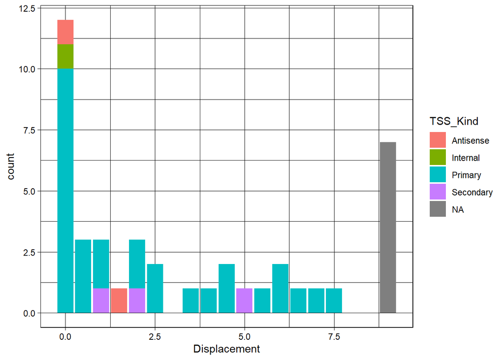

```r
t4_p061 <- ggplot(t4_df_061_plot, aes(Displacement))+
  geom_bar(aes(fill=TSS_Kind))+
  theme_linedraw()
t4_p061
```

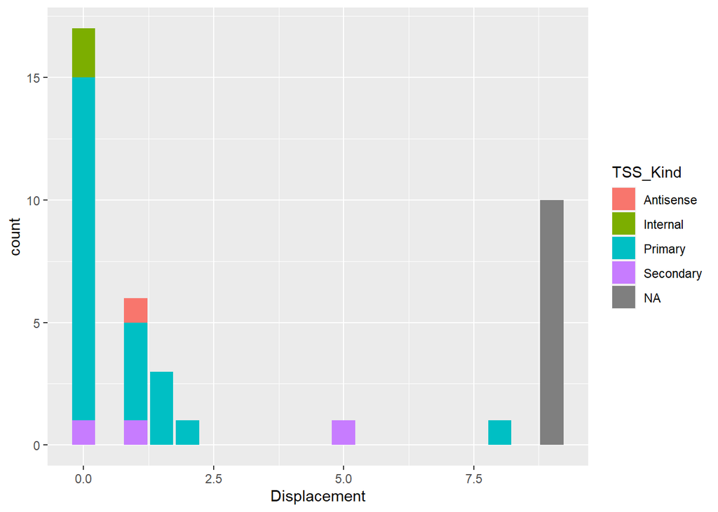

```r
t4_p065 <- ggplot(t4_df_065_plot, aes(Displacement))+
  geom_bar(aes(fill=TSS_Kind))
t4_p065
```

```r
#Mean displacement
r1 <- sum(t4_df_061_plot$Displacement)/nrow(t4_df_061_plot)
r1
```

```
## [1] 3.333333
```

```r
r2 <- sum(t4_df_065_plot$Displacement)/nrow(t4_df_065_plot)
r2
```

```
## [1] 2.961538
```

## 2.4 Plot information on TSS type abundance

Therefore, count appearance of each TSS type and create a table for the pie chart.

```r
t4_df_pie_061 <- count_appearance(t4_df_061_calc)
t4_df_pie_061
```

```
##        Type Count
## 1 Secondary     3
## 2   Primary    29
## 3      <NA>     7
## 4 Antisense     2
## 5  Internal     1
```

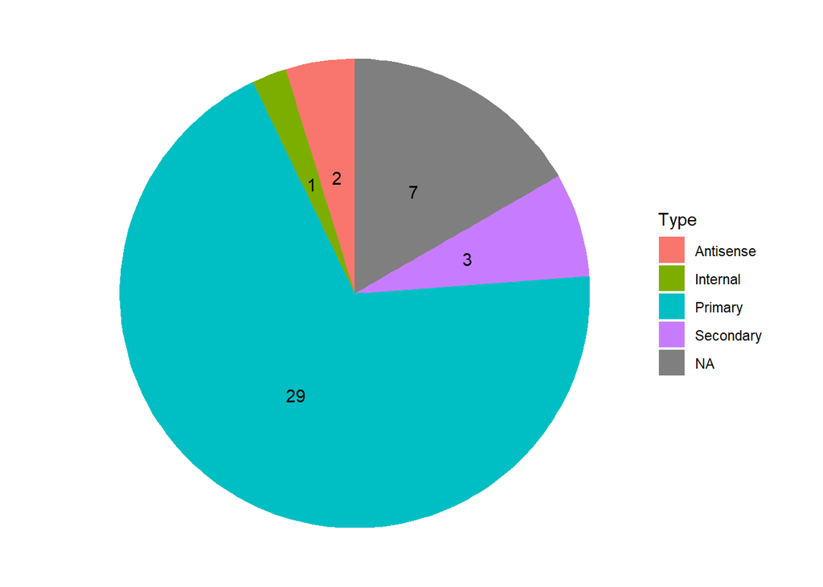

```r
t4_pie061 <- ggplot(t4_df_pie_061, aes(x="", y=Count, fill=Type))+
  geom_bar(width = 1, stat = "identity")+
  coord_polar("y", start=0)+
  geom_text(aes(label = Count), position = position_stack(vjust = 0.5))+
  theme_void()
t4_pie061
```

```r
t4_df_pie_065 <- count_appearance(t4_df_065_calc)
t4_df_pie_065
```

```
##        Type Count
## 1 Secondary     3
## 2   Primary    23
## 3      <NA>    10
## 4  Internal     2
## 5 Antisense     1
```

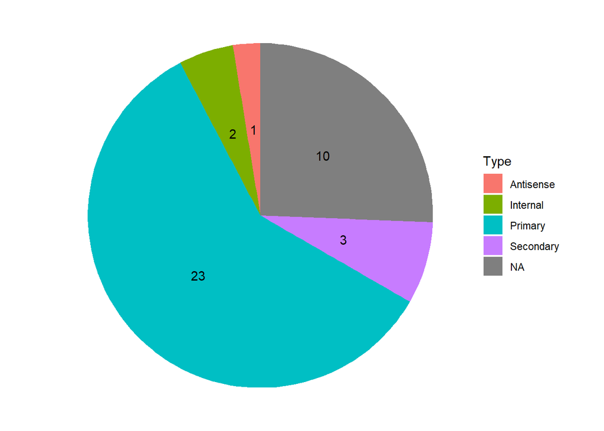

```r
t4_pie065 <- ggplot(t4_df_pie_065, aes(x="", y=Count, fill=Type))+
  geom_bar(width = 1, stat = "identity")+
  coord_polar("y", start=0)+
  geom_text(aes(label = Count), position = position_stack(vjust = 0.5))+
  theme_void()
t4_pie065
```